# Homework-III

Nishan Khanal

```r
library(tidyverse)
library(tidymodels)
library(ggformula)
library(GGally)
library(ISLR)
library(skimr)
```

Backward selection

Use the Auto dataset (can be found in ISLR R package). Our objectives: - Predict acceleration using the remaining quantitative variables. - Which, if any, of the variables are significant predictors of acceleration. - How good is the resulting prediction?

1. Remove the name and origin columns from the dataset. Then
- Produce a ggpairs plot. Write a short discussion (2–3 sentences) about what the plot suggests for multiple linear regression (collinearity, pairwise relationships, etc.).
2. Start from the full model with all quantitative predictors. Do a manual backward selection using p-values to determine what to remove until all predictors are significant at the α = 0.05 level. Filter the tidy() output to show only candidates for removal, i.e. p-values > α. Remove the predictor with the largest p-value at each step. Compare the full (unfiltered) tidy() results and adjusted R2 at each step to the previous step.
3. With the final model (from (2)), check residuals, interpret coefficients, report confidence intervals on coefficients.

Load the auto data and skim it to know more about data dimension, data types and completion rate.

```r
data(Auto, package="ISLR")
glimpse(Auto)
```

```
## Rows: 392
## Columns: 9
## $ mpg          <dbl> 18, 15, 18, 16, 17, 15, 14, 14, 14, 15, 15, 14, 15, 14, 2…
## $ cylinders    <dbl> 8, 8, 8, 8, 8, 8, 8, 8, 8, 8, 8, 8, 8, 8, 4, 6, 6, 6, 4, …
## $ displacement <dbl> 307, 350, 318, 304, 302, 429, 454, 440, 455, 390, 383, 34…
## $ horsepower   <dbl> 130, 165, 150, 150, 140, 198, 220, 215, 225, 190, 170, 16…
## $ weight       <dbl> 3504, 3693, 3436, 3433, 3449, 4341, 4354, 4312, 4425, 385…
## $ acceleration <dbl> 12.0, 11.5, 11.0, 12.0, 10.5, 10.0, 9.0, 8.5, 10.0, 8.5, …
## $ year         <dbl> 70, 70, 70, 70, 70, 70, 70, 70, 70, 70, 70, 70, 70, 70, 7…
## $ origin       <dbl> 1, 1, 1, 1, 1, 1, 1, 1, 1, 1, 1, 1, 1, 1, 3, 1, 1, 1, 3, …
## $ name         <fct> chevrolet chevelle malibu, buick skylark 320, plymouth sa…
```

Let’s know more about the different variables in this dataset:

`mpg`: miles per gallon

`cylinders`: Number of cylinders between 4 and 8

`displacement`: Engine displacement (cu. inches)

`horsepower`: Engine horsepower

`weight`: Vehicle weight (lbs.)

`acceleration`: Time to accelerate from 0 to 60 mph (sec.)

`year`: Model year (modulo 100)

`origin`: Origin of car (1. American, 2. European, 3. Japanese)

`name`: Vehicle name

Discard the name and origin column and skim the dataset

```r
auto <- Auto |>
  dplyr::select(-name, -origin)

skim(auto)
```

Data summary

| Name | auto |
| --- | --- |
| Number of rows | 392 |
| Number of columns | 7 |
| _______________________ |  |
| Column type frequency: |  |
| numeric | 7 |
| ________________________ |  |
| Group variables | None |

**Variable type: numeric**

| skim_variable | n_missing | complete_rate | mean | sd | p0 | p25 | p50 | p75 | p100 | hist |
| --- | --- | --- | --- | --- | --- | --- | --- | --- | --- | --- |
| mpg | 0 | 1 | 23.45 | 7.81 | 9 | 17.00 | 22.75 | 29.00 | 46.6 | ▆▇▆▃▁ |
| cylinders | 0 | 1 | 5.47 | 1.71 | 3 | 4.00 | 4.00 | 8.00 | 8.0 | ▇▁▃▁▅ |
| displacement | 0 | 1 | 194.41 | 104.64 | 68 | 105.00 | 151.00 | 275.75 | 455.0 | ▇▂▂▃▁ |
| horsepower | 0 | 1 | 104.47 | 38.49 | 46 | 75.00 | 93.50 | 126.00 | 230.0 | ▆▇▃▁▁ |
| weight | 0 | 1 | 2977.58 | 849.40 | 1613 | 2225.25 | 2803.50 | 3614.75 | 5140.0 | ▇▇▅▅▂ |
| acceleration | 0 | 1 | 15.54 | 2.76 | 8 | 13.78 | 15.50 | 17.02 | 24.8 | ▁▆▇▂▁ |
| year | 0 | 1 | 75.98 | 3.68 | 70 | 73.00 | 76.00 | 79.00 | 82.0 | ▇▆▇▆▇ |

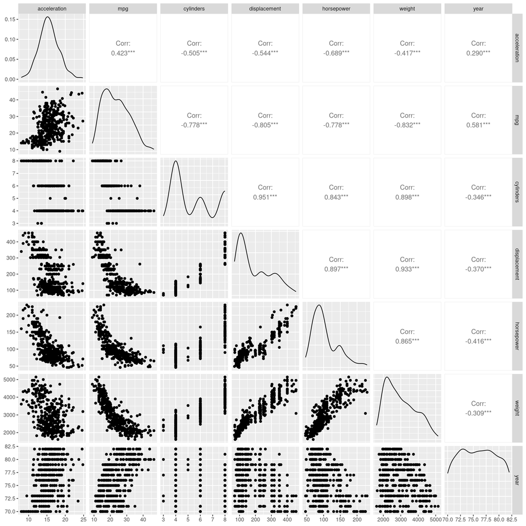

```r
auto |>
  select(acceleration, everything()) |>
  ggpairs()
```

We can also notice our predictors are highly correlated with each other. For example the correlation between cylinders and displacement is 0.951 - very strong. Other strong correlation include between displacement and weight, cylinders and horsepower, cylinders and weight, displacement and horsepower, displacement and mpg, horsepower and weight, and weight and mpg. This can cause issue when fitting the model due to multicollinearity.

# Question 2

Start from the full model with all quantitative predictors. Do a manual backward selection using p-values to determine what to remove until all predictors are significant at the α = 0.05 level. Filter the tidy() output to show only candidates for removal, i.e. p-values > α. Remove the predictor with the largest p-value at each step. Compare the full (unfiltered) tidy() results and adjusted R2 at each step to the previous step.

Since we will be fitting a model multiple times with backward elimination, and report the output, let’s create a reusable function to report the output

```r
library(flextable)
report_step <- function(mod, step_label = "Step", alpha=0.05) {
  td <- tidy(mod)
  gl <- glance(mod)

  cat(step_label, "\n")

  cat("model Glance")
  cat("Adjusted R-squared:", round(gl$adj.r.squared, 5), "\n\n")

  cat("FULL tidy():\n")
  flextable(td)

  cat("\nCandidates for removal (p.value > alpha):\n")
  cand <- td |>
    filter(term != "(Intercept)", p.value > alpha) |>
    arrange(desc(p.value))

  print(cand)

  invisible(list(tidy = td, glance = gl, candidates = cand))
}

# create a specification for a linear regression model
lm_spec <- linear_reg() |>
  set_mode("regression") |>
  set_engine("lm")
```

## Step 1: Full model (all the predictors)

```r
formula_1 <- acceleration ~ mpg + cylinders + displacement + horsepower + weight + year

model_1 <- lm_spec |>
  fit(formula_1, data = auto)

output_1 <- report_step(model_1, "Step 1: Full model")
```

[output not shown]